# R Notebook

```r
library(spotifyr)
library(tidyverse)
library(modelr)
library(infer)
```

```r
spotify_clean_join <- read_csv("clean_data/spotify_clean_join.csv")
```

### Hypothesis Testing for Audio Features

H0: The mean acousticness in 1960s is the same as the mean acousticness in 2010s

Ha: The mean acousticness in 1960s is different than the mean acousticness in 2010s

H0: mean(acousticness_2020) - mean(acousticness_1960) = 0 Ha: acousticness_2020 - acousticness_1960 <> 0

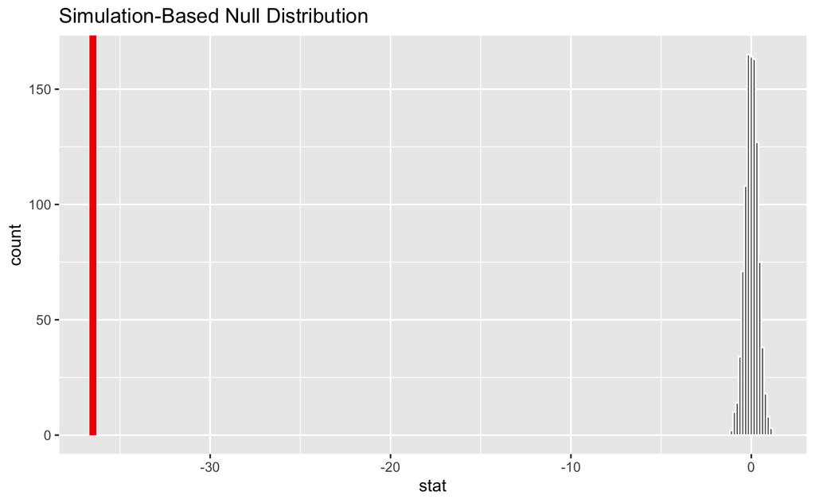

```r
acoustic_decade_hyp <- spotify_clean_join %>%
  select(decade, acousticness) %>%
  filter(decade == 1960 | decade == 2010) %>%
  mutate(decade = as.factor(decade))

null_distribution <- acoustic_decade_hyp %>%
  specify(acousticness ~ decade) %>%
  hypothesize(null = "independence") %>%
  generate(reps = 1000, type = "permute") %>%
  calculate(stat = "diff in means", order = c("2010", "1960"))

observed_stat <- acoustic_decade_hyp %>%
  specify(acousticness ~ decade) %>%
  calculate(stat = "diff in means", order = c("2010", "1960"))

null_distribution %>%
  visualise() +
  shade_p_value(obs_stat = observed_stat, direction = "both")
```

```r
p_value <- null_distribution %>%
  get_p_value(obs_stat = observed_stat, direction = "both")
```

H0: The mean danceability in 1960s is the same as the mean danceability in 2010s

Ha: The mean danceability in 1960s is different than the mean danceability in 2010s

H0: mean(danceability_2020) - mean(danceability_1960) = 0 Ha: danceability_2020 - danceability_1960 <> 0

```r
dance_decade_hyp <- spotify_clean_join %>%
  select(decade, danceability) %>%
  filter(decade == 1960 | decade == 2010) %>%
  mutate(decade = as.factor(decade))

null_distribution <- dance_decade_hyp %>%
  specify(danceability ~ decade) %>%
  hypothesize(null = "independence") %>%
  generate(reps = 1000, type = "permute") %>%
  calculate(stat = "diff in means", order = c("2010", "1960"))

observed_stat <- dance_decade_hyp %>%
  specify(danceability ~ decade) %>%
  calculate(stat = "diff in means", order = c("2010", "1960"))

null_distribution %>%
  visualise() +
  shade_p_value(obs_stat = observed_stat, direction = "both")

p_value <- null_distribution %>%
  get_p_value(obs_stat = observed_stat, direction = "both")
```

[output not shown]

H0: The mean energy in 1960s is the same as the mean energy in 2010s

Ha: The mean energy in 1960s is different than the mean energy in 2010s

H0: mean(energy_2020) - mean(energy_1960) = 0 Ha: energy2020 - energy_1960 <> 0

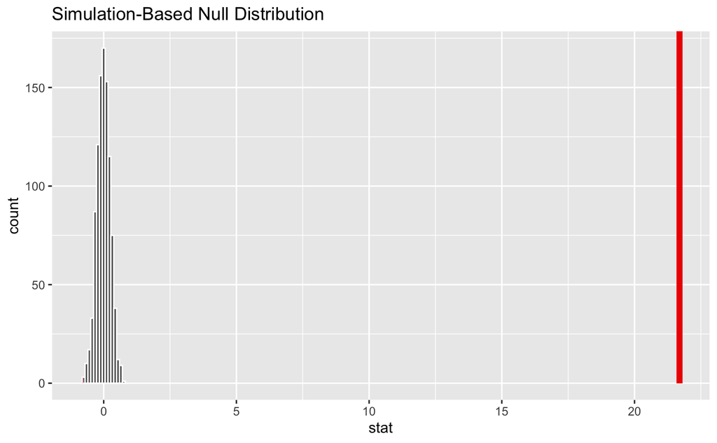

```r
energy_decade_hyp <- spotify_clean_join %>%
  select(decade, energy) %>%
  filter(decade == 1960 | decade == 2010) %>%
  mutate(decade = as.factor(decade))

null_distribution <- energy_decade_hyp %>%
  specify(energy ~ decade) %>%
  hypothesize(null = "independence") %>%
  generate(reps = 1000, type = "permute") %>%
  calculate(stat = "diff in means", order = c("2010", "1960"))

observed_stat <- energy_decade_hyp %>%
  specify(energy ~ decade) %>%
  calculate(stat = "diff in means", order = c("2010", "1960"))

null_distribution %>%
  visualise() +
  shade_p_value(obs_stat = observed_stat, direction = "both")
```

```r
p_value <- null_distribution %>%
  get_p_value(obs_stat = observed_stat, direction = "both")
```

H0: The mean instrumentalness in 1960s is the same as the mean instrumentalness in 2010s

Ha: The mean instrumentalness in 1960s is different than the mean instrumentalness in 2010s

H0: mean(instrumentalness_2020) - mean(instrumentalness_1960) = 0 Ha: instrumentalness_2020 - instrumentalness_1960 <> 0

```r
inst_decade_hyp <- spotify_clean_join %>%
  select(decade, instrumentalness) %>%
  filter(decade == 1960 | decade == 2010) %>%
  mutate(decade = as.factor(decade))

null_distribution <- inst_decade_hyp %>%
  specify(instrumentalness ~ decade) %>%
  hypothesize(null = "independence") %>%
  generate(reps = 1000, type = "permute") %>%
  calculate(stat = "diff in means", order = c("2010", "1960"))

observed_stat <- inst_decade_hyp %>%
  specify(instrumentalness ~ decade) %>%
  calculate(stat = "diff in means", order = c("2010", "1960"))

null_distribution %>%
  visualise() +
  shade_p_value(obs_stat = observed_stat, direction = "both")

p_value <- null_distribution %>%
  get_p_value(obs_stat = observed_stat, direction = "both")
```

[output not shown]

H0: The mean liveness in 1960s is the same as the mean liveness in 2010s

Ha: The mean liveness in 1960s is different than the mean liveness in 2010s

H0: mean(liveness_2020) - mean(liveness_1960) = 0 Ha: liveness_2020 - liveness_1960 <> 0

```r
live_decade_hyp <- spotify_clean_join %>%
  select(decade, liveness) %>%
  filter(decade == 1960 | decade == 2010) %>%
  mutate(decade = as.factor(decade))

null_distribution <- live_decade_hyp %>%
  specify(liveness ~ decade) %>%
  hypothesize(null = "independence") %>%
  generate(reps = 1000, type = "permute") %>%
  calculate(stat = "diff in means", order = c("2010", "1960"))

observed_stat <- live_decade_hyp %>%
  specify(liveness ~ decade) %>%
  calculate(stat = "diff in means", order = c("2010", "1960"))

null_distribution %>%
  visualise() +
  shade_p_value(obs_stat = observed_stat, direction = "both")

p_value <- null_distribution %>%
  get_p_value(obs_stat = observed_stat, direction = "both")
```

[output not shown]

H0: The mean loudness in 1960s is the same as the mean loudness in 2010s

Ha: The mean loudness in 1960s is different than the mean loudness in 2010s

H0: mean(loudness_2020) - mean(loudness_1960) = 0 Ha: loudness_2020 - loudness_1960 <> 0

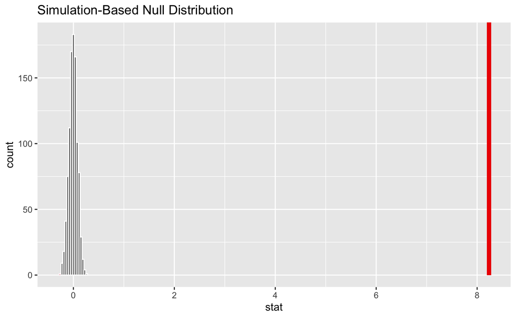

```r
loud_decade_hyp <- spotify_clean_join %>%
  select(decade, loudness) %>%
  filter(decade == 1960 | decade == 2010) %>%
  mutate(decade = as.factor(decade))

null_distribution <- loud_decade_hyp %>%
  specify(loudness ~ decade) %>%
  hypothesize(null = "independence") %>%
  generate(reps = 1000, type = "permute") %>%
  calculate(stat = "diff in means", order = c("2010", "1960"))

observed_stat <- loud_decade_hyp %>%
  specify(loudness ~ decade) %>%
  calculate(stat = "diff in means", order = c("2010", "1960"))

null_distribution %>%
  visualise() +
  shade_p_value(obs_stat = observed_stat, direction = "both")
```

```r
p_value <- null_distribution %>%
  get_p_value(obs_stat = observed_stat, direction = "both")
```

H0: The mean speechiness in 1960s is the same as the mean speechiness in 2010s

Ha: The mean speechiness in 1960s is different than the mean speechiness in 2010s

H0: mean(speechiness_2020) - mean(speechiness_1960) = 0 Ha: speechiness_2020 - speechiness_1960 <> 0

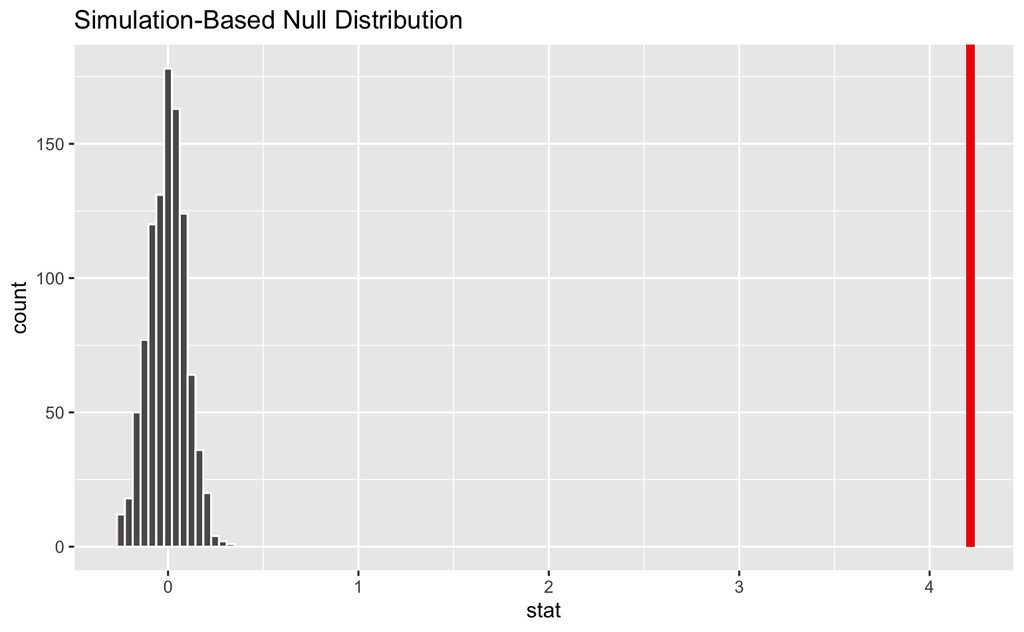

```r
speech_decade_hyp <- spotify_clean_join %>%
  select(decade, speechiness) %>%
  filter(decade == 1960 | decade == 2010) %>%
  mutate(decade = as.factor(decade))

null_distribution <- speech_decade_hyp %>%
  specify(speechiness ~ decade) %>%
  hypothesize(null = "independence") %>%
  generate(reps = 1000, type = "permute") %>%
  calculate(stat = "diff in means", order = c("2010", "1960"))

observed_stat <- speech_decade_hyp %>%
  specify(speechiness ~ decade) %>%
  calculate(stat = "diff in means", order = c("2010", "1960"))

null_distribution %>%
  visualise() +
  shade_p_value(obs_stat = observed_stat, direction = "both")
```

```r
p_value <- null_distribution %>%
  get_p_value(obs_stat = observed_stat, direction = "both")
```

H0: The mean valence in 1960s is the same as the mean valence in 2010s

Ha: The mean valence in 1960s is different than the mean valence in 2010s

H0: mean(valence_2020) - mean(valence_1960) = 0 Ha: valence_2020 - valence_1960 <> 0

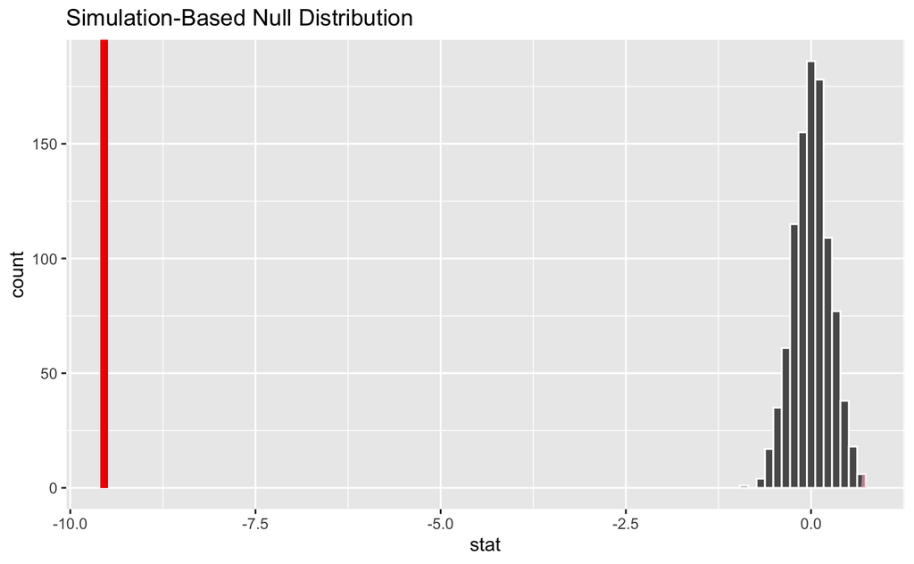

```r
valence_decade_hyp <- spotify_clean_join %>%
  select(decade, valence) %>%
  filter(decade == 1960 | decade == 2010) %>%
  mutate(decade = as.factor(decade))

null_distribution <- valence_decade_hyp %>%
  specify(valence ~ decade) %>%
  hypothesize(null = "independence") %>%
  generate(reps = 1000, type = "permute") %>%
  calculate(stat = "diff in means", order = c("2010", "1960"))

observed_stat <- valence_decade_hyp %>%
  specify(valence ~ decade) %>%
  calculate(stat = "diff in means", order = c("2010", "1960"))

null_distribution %>%
  visualise() +
  shade_p_value(obs_stat = observed_stat, direction = "both")
```

```r
p_value <- null_distribution %>%
  get_p_value(obs_stat = observed_stat, direction = "both")
```

### Hypothesis test for difference in popularity means

H0: mean(popularity_2020) - mean(popularity_1960) = 0 Ha: popularity_2020 - popularity_1960 <> 0

```r
pop_decade_hyp <- spotify_clean_join %>%
  select(year, popularity) %>%
  filter(year == 1960 | year == 2010) %>%
  mutate(year = as.factor(year))

null_distribution <- pop_decade_hyp %>%
  specify(popularity ~ year) %>%
  hypothesize(null = "independence") %>%
  generate(reps = 1000, type = "permute") %>%
  calculate(stat = "diff in means", order = c("2010", "1960"))

observed_stat <- pop_decade_hyp %>%
  specify(popularity ~ year) %>%
  calculate(stat = "diff in means", order = c("2010", "1960"))

null_distribution %>%
  visualise() +
  shade_p_value(obs_stat = observed_stat, direction = "both")

p_value <- null_distribution %>%
  get_p_value(obs_stat = observed_stat, direction = "both")
```

[output not shown]